# Applying Machine Learning to Predict Exercise Quality

Andrew Messier

Saturday, June 20, 2015

## Summary

The purpose of this assignment is to use machine learning to build a model that predicts the manner in which an exercise was performed. There is an appropriate way to perform the exercise, and 4 ways in which it is commonly done incorrectly, labeled in the supplied dataset as A, B, C, D and E. The data is taken from the following source:

http://groupware.les.inf.puc-rio.br/har

## Loading the data

First, I loaded the dataset into the R workspace

```r
library(caret)
data_raw<-read.csv("pml-training.csv")
```

I first viewed this data in Excel to see the trends and noticed that many of the fields were left empty or filled with invalid values such as Div0 or NaN. The following command selects the features that are valid numeric values of sensors. The first index is the ‘classe’ variable which is the factor value we are trying to predict:

```r
training<-data_raw[,c("classe",
                      "roll_belt","pitch_belt","yaw_belt","total_accel_belt",
                      "gyros_belt_x","gyros_belt_y","gyros_belt_z",
                      "accel_belt_x","accel_belt_y","accel_belt_z",
                      "magnet_belt_x","magnet_belt_y","magnet_belt_z",
                      "roll_arm","pitch_arm","yaw_arm","total_accel_arm",
                      "gyros_arm_x","gyros_arm_y","gyros_arm_z",
                      "accel_arm_x","accel_arm_y","accel_arm_z",
                      "magnet_arm_x","magnet_arm_y","magnet_arm_z",
                      "roll_dumbbell","pitch_dumbbell","yaw_dumbbell","total_accel_dumbbell",
                      "gyros_dumbbell_x","gyros_dumbbell_y","gyros_dumbbell_z",
                      "accel_dumbbell_x","accel_dumbbell_y","accel_dumbbell_z",
                      "magnet_dumbbell_x","magnet_dumbbell_y","magnet_dumbbell_z",
                      "roll_forearm","pitch_forearm","yaw_forearm","total_accel_forearm",
                      "gyros_forearm_x","gyros_forearm_y","gyros_forearm_z",
                      "accel_forearm_x","accel_forearm_y","accel_forearm_z",
                      "magnet_forearm_x","magnet_forearm_y","magnet_forearm_z")]
```

## Exploratory data analysis

Now that we have the data in a format that is useable, we can do some exploratory data analysis to see what types of trends can be seen. This dataset has 52 features so it would be overwhelming to look at them all. Instead, I used the values from the ‘belt’ sensors and am looking at the pairs of parameters with the markers color-coded by exercise type.

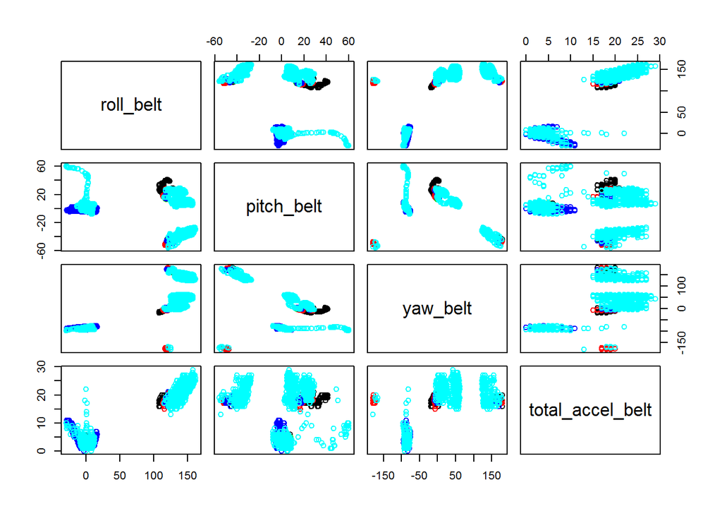

```r
pairs(subset(training,select=roll_belt:total_accel_belt),col=training$classe)
```

```r
modFit_tree<-train(classe ~ .,method="rpart",data=training)
print(modFit_tree$finalModel)
```

```
## n= 19622
##
## node), split, n, loss, yval, (yprob)
##       * denotes terminal node
##
##  1) root 19622 14042 A (0.28 0.19 0.17 0.16 0.18)
##    2) roll_belt< 130.5 17977 12411 A (0.31 0.21 0.19 0.18 0.11)
##      4) pitch_forearm< -33.95 1578    10 A (0.99 0.0063 0 0 0) *
##      5) pitch_forearm>=-33.95 16399 12401 A (0.24 0.23 0.21 0.2 0.12)
##       10) magnet_dumbbell_y< 439.5 13870  9953 A (0.28 0.18 0.24 0.19 0.11)
##         20) roll_forearm< 123.5 8643  5131 A (0.41 0.18 0.18 0.17 0.061) *
##         21) roll_forearm>=123.5 5227  3500 C (0.077 0.18 0.33 0.23 0.18) *
##       11) magnet_dumbbell_y>=439.5 2529  1243 B (0.032 0.51 0.043 0.22 0.19) *
##    3) roll_belt>=130.5 1645    14 E (0.0085 0 0 0 0.99) *
```

```r
table(predict(modFit_tree,training),training$classe)
```

```
##
##        A    B    C    D    E
##   A 5080 1581 1587 1449  524
##   B   81 1286  108  568  486
##   C  405  930 1727 1199  966
##   D    0    0    0    0    0
##   E   14    0    0    0 1631
```

This model is inadequate for a couple of reasons. First of all, it never predicts ‘D’, and the other predictions are not sufficiently accurate for any prediction. To get a perfect grade on the submission, we need to predict 20/20 sample points. This means we should have a goal of better than 95% accuracy.

Instead, we fit a random forest model:

```r
library(randomForest)
modFit_forest<-randomForest(classe ~ .,data=training)
print(modFit_forest)
```

```
##
## Call:
##  randomForest(formula = classe ~ ., data = training)
##                Type of random forest: classification
##                      Number of trees: 500
## No. of variables tried at each split: 7
##
##         OOB estimate of  error rate: 0.28%
## Confusion matrix:
##      A    B    C    D    E  class.error
## A 5577    2    0    0    1 0.0005376344
## B    9 3785    3    0    0 0.0031603898
## C    0   11 3410    1    0 0.0035067212
## D    0    0   20 3194    2 0.0068407960
## E    0    0    0    5 3602 0.0013861935
```

This result shows an “out of bag” error of 0.28%. This is a measure of cross-validation and shows that the model should have excellent prediction performance outside of the training set. Furthermore, this model successfully predicted the 20 test points supplied for this assignment.